# Customer Churn Prediction

# Synopsis

In telecommunications, a big part of customer relationship management involves efforts to retain existing customers. In many cases, the costs incurred to attract new customers are much larger than the costs to retain the existing customers.

This project is focused on creating the best model to predict customer churn to help us make decisions on what incentives we can give to customers planning to churn.

We will do this by:

1. Cleaning our data set.
2. Exploring trends through data analysis/data visualization.
3. Creating and evaluating model performance.
4. Exploring trends within the optimal model.

# Libraries

```r
library(tidyverse)
library(tidymodels)
library(here)
library(vip)
library(pdp)
library(DT)
library(ggplot2)
library(cowplot)
library(DALEXtra)
```

# Data Exploration

Below we are going to look into the structure of our data set.

```r
path <- here('data', 'customer_retention.csv')
df <- read_csv(path)


datatable(head(df))
```

|  | Gender | SeniorCitizen | Partner | Dependents | Tenure | PhoneService | MultipleLines | InternetService | OnlineSecurity | OnlineBackup | DeviceProtection | TechSupport | StreamingTV | StreamingMovies | Contract | PaperlessBilling | PaymentMethod | MonthlyCharges | TotalCharges | Status |
| --- | --- | --- | --- | --- | --- | --- | --- | --- | --- | --- | --- | --- | --- | --- | --- | --- | --- | --- | --- | --- |
| 1 | Female | 0 | Yes | No | 1 | No | No phone service | DSL | No | Yes | No | No | No | No | Month-to-month | Yes | Electronic check | 29.85 | 29.85 | Current |
| 2 | Male | 0 | No | No | 34 | Yes | No | DSL | Yes | No | Yes | No | No | No | One year | No | Mailed check | 56.95 | 1889.5 | Current |
| 3 | Male | 0 | No | No | 2 | Yes | No | DSL | Yes | Yes | No | No | No | No | Month-to-month | Yes | Mailed check | 53.85 | 108.15 | Left |
| 4 | Male | 0 | No | No | 45 | No | No phone service | DSL | Yes | No | Yes | Yes | No | No | One year | No | Bank transfer (automatic) | 42.3 | 1840.75 | Current |
| 5 | Female | 0 | No | No | 2 | Yes | No | Fiber optic | No | No | No | No | No | No | Month-to-month | Yes | Electronic check | 70.7 | 151.65 | Left |
| 6 | Female | 0 | No | No | 8 | Yes | Yes | Fiber optic | No | No | Yes | No | Yes | Yes | Month-to-month | Yes | Electronic check | 99.65 | 820.5 | Left |

```r
str(df)
```

```
## spc_tbl_ [6,999 × 20] (S3: spec_tbl_df/tbl_df/tbl/data.frame)
##  $ Gender          : chr [1:6999] "Female" "Male" "Male" "Male" ...
##  $ SeniorCitizen   : num [1:6999] 0 0 0 0 0 0 0 0 0 0 ...
##  $ Partner         : chr [1:6999] "Yes" "No" "No" "No" ...
##  $ Dependents      : chr [1:6999] "No" "No" "No" "No" ...
##  $ Tenure          : num [1:6999] 1 34 2 45 2 8 22 10 28 62 ...
##  $ PhoneService    : chr [1:6999] "No" "Yes" "Yes" "No" ...
##  $ MultipleLines   : chr [1:6999] "No phone service" "No" "No" "No phone service" ...
##  $ InternetService : chr [1:6999] "DSL" "DSL" "DSL" "DSL" ...
##  $ OnlineSecurity  : chr [1:6999] "No" "Yes" "Yes" "Yes" ...
##  $ OnlineBackup    : chr [1:6999] "Yes" "No" "Yes" "No" ...
##  $ DeviceProtection: chr [1:6999] "No" "Yes" "No" "Yes" ...
##  $ TechSupport     : chr [1:6999] "No" "No" "No" "Yes" ...
##  $ StreamingTV     : chr [1:6999] "No" "No" "No" "No" ...
##  $ StreamingMovies : chr [1:6999] "No" "No" "No" "No" ...
##  $ Contract        : chr [1:6999] "Month-to-month" "One year" "Month-to-month" "One year" ...
##  $ PaperlessBilling: chr [1:6999] "Yes" "No" "Yes" "No" ...
##  $ PaymentMethod   : chr [1:6999] "Electronic check" "Mailed check" "Mailed check" "Bank transfer (automatic)" ...
##  $ MonthlyCharges  : num [1:6999] 29.9 57 53.9 42.3 70.7 ...
##  $ TotalCharges    : num [1:6999] 29.9 1889.5 108.2 1840.8 151.7 ...
##  $ Status          : chr [1:6999] "Current" "Current" "Left" "Current" ...
##  - attr(*, "spec")=
##   .. cols(
##   ..   Gender = col_character(),
##   ..   SeniorCitizen = col_double(),
##   ..   Partner = col_character(),
##   ..   Dependents = col_character(),
##   ..   Tenure = col_double(),
##   ..   PhoneService = col_character(),
##   ..   MultipleLines = col_character(),
##   ..   InternetService = col_character(),
##   ..   OnlineSecurity = col_character(),
##   ..   OnlineBackup = col_character(),
##   ..   DeviceProtection = col_character(),
##   ..   TechSupport = col_character(),
##   ..   StreamingTV = col_character(),
##   ..   StreamingMovies = col_character(),
##   ..   Contract = col_character(),
##   ..   PaperlessBilling = col_character(),
##   ..   PaymentMethod = col_character(),
##   ..   MonthlyCharges = col_double(),
##   ..   TotalCharges = col_double(),
##   ..   Status = col_character()
##   .. )
##  - attr(*, "problems")=<externalptr>
```

## About the Data

Below are our feature variables ($X$):

- *Gender*: Whether the customer is a male or a female
- *SeniorCitizen*: Whether the customer is a senior citizen or not (1, 0)
- *Partner*: Whether the customer has a partner or not (Yes, No)
- *Dependents*: Whether the customer has dependents or not (Yes, No)
- *Tenure*: Number of months the customer has stayed with the company
- *PhoneService*: Whether the customer has a phone service or not (Yes, No)
- *MultipleLines*: Whether the customer has multiple lines or not (Yes, No, No phone service)
- *InternetService*: Customer’s internet service provider (DSL, Fiber optic, No)
- *OnlineSecurity*: Whether the customer has online security or not (Yes, No, No internet service)
- *OnlineBackup*: Whether the customer has online backup or not (Yes, No, No internet service)
- *DeviceProtection*: Whether the customer has device protection or not (Yes, No, No internet service)
- *TechSupport*: Whether the customer has tech support or not (Yes, No, No internet service)
- *StreamingTV*: Whether the customer has streaming TV or not (Yes, No, No internet service)
- *StreamingMovies*: Whether the customer has streaming movies or not (Yes, No, No internet service)
- *Contract*: The contract term of the customer (Month-to-month, One year, Two year)
- *PaperlessBilling*: Whether the customer has paperless billing or not (Yes, No)
- *PaymentMethod*: The customer’s payment method (Electronic check, Mailed check, Bank transfer (automatic), Credit card (automatic))
- *MonthlyCharges*: The amount charged to the customer monthly
- *TotalCharges*: The total amount charged to the customer

Below is our response variable ($Y$):

- *Status*: Whether the customer is Current or has Left.

Checking for nulls:

```r
colSums(is.na(df))
```

```
##           Gender    SeniorCitizen          Partner       Dependents
##                0                0                0                0
##           Tenure     PhoneService    MultipleLines  InternetService
##                0                0                0                0
##   OnlineSecurity     OnlineBackup DeviceProtection      TechSupport
##                0                0                0                0
##      StreamingTV  StreamingMovies         Contract PaperlessBilling
##                0                0                0                0
##    PaymentMethod   MonthlyCharges     TotalCharges           Status
##                0                0               11                0
```

Removing nulls:

```r
df <- na.omit(df)
colSums(is.na(df))
```

```
##           Gender    SeniorCitizen          Partner       Dependents
##                0                0                0                0
##           Tenure     PhoneService    MultipleLines  InternetService
##                0                0                0                0
##   OnlineSecurity     OnlineBackup DeviceProtection      TechSupport
##                0                0                0                0
##      StreamingTV  StreamingMovies         Contract PaperlessBilling
##                0                0                0                0
##    PaymentMethod   MonthlyCharges     TotalCharges           Status
##                0                0                0                0
```

Data Types:

```r
df %>% map(class)
```

```
## $Gender
## [1] "character"
##
## $SeniorCitizen
## [1] "numeric"
##
## $Partner
## [1] "character"
##
## $Dependents
## [1] "character"
##
## $Tenure
## [1] "numeric"
##
## $PhoneService
## [1] "character"
##
## $MultipleLines
## [1] "character"
##
## $InternetService
## [1] "character"
##
## $OnlineSecurity
## [1] "character"
##
## $OnlineBackup
## [1] "character"
##
## $DeviceProtection
## [1] "character"
##
## $TechSupport
## [1] "character"
##
## $StreamingTV
## [1] "character"
##
## $StreamingMovies
## [1] "character"
##
## $Contract
## [1] "character"
##
## $PaperlessBilling
## [1] "character"
##
## $PaymentMethod
## [1] "character"
##
## $MonthlyCharges
## [1] "numeric"
##
## $TotalCharges
## [1] "numeric"
##
## $Status
## [1] "character"
```

We are going to convert our binary feature *SeniorCitizen* to a character for our analysis:

```r
df$SeniorCitizen[df$SeniorCitizen == 0] <- 'No'
df$SeniorCitizen[df$SeniorCitizen == 1] <- 'Yes'
```

# Exploratory Data Analysis

In this section, we are going to look at our data distributions and correlations among features with each other and features with our $Y$.

## Distributions

Below we are going to look at the distributions for our $Y$:

```r
# function for plotting distribution
cat_distribution <- function(x) {

  col = df[[x]]

  ggplot() +
    geom_bar(aes(col, fill = df[['Status']])) +
    labs(
      title = paste(x, 'Distribution'),
      fill = 'Status',
      x = x,
      y = 'Count'
    ) +
    theme(
      plot.title = element_text(hjust = 0.5),
      axis.text.x = element_text(size = 6)
      )
}
```

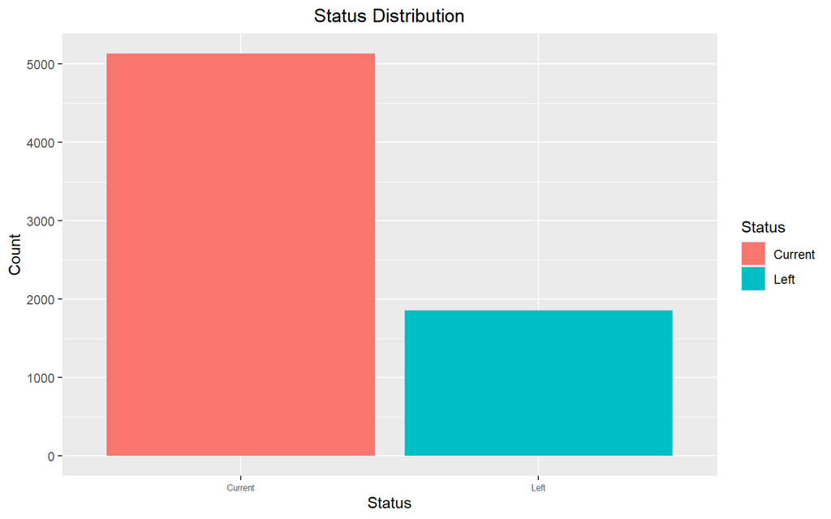

```r
cat_distribution('Status')
```

Now we are going to quickly look at our distributions for our categorical features:

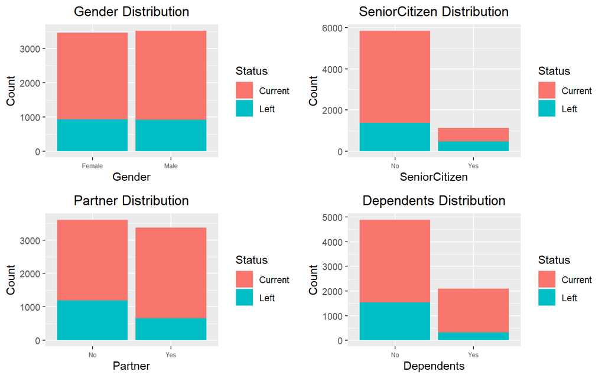

```r
cat_features <- colnames(
  df %>%
  select_if(is.character) %>%
  select(-Status)
  )

df$PaymentMethod[df$PaymentMethod == "Bank transfer (automatic)"] <- "Bank transfer"

df$PaymentMethod[df$PaymentMethod == "Credit card (automatic)"] <- "Credit card"

plot_list <- map(cat_features, cat_distribution)
plot_grid(plotlist = plot_list[1:4])
```

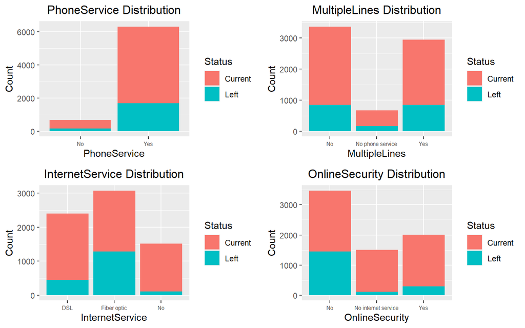

```r
plot_grid(plotlist = plot_list[5:8])
```

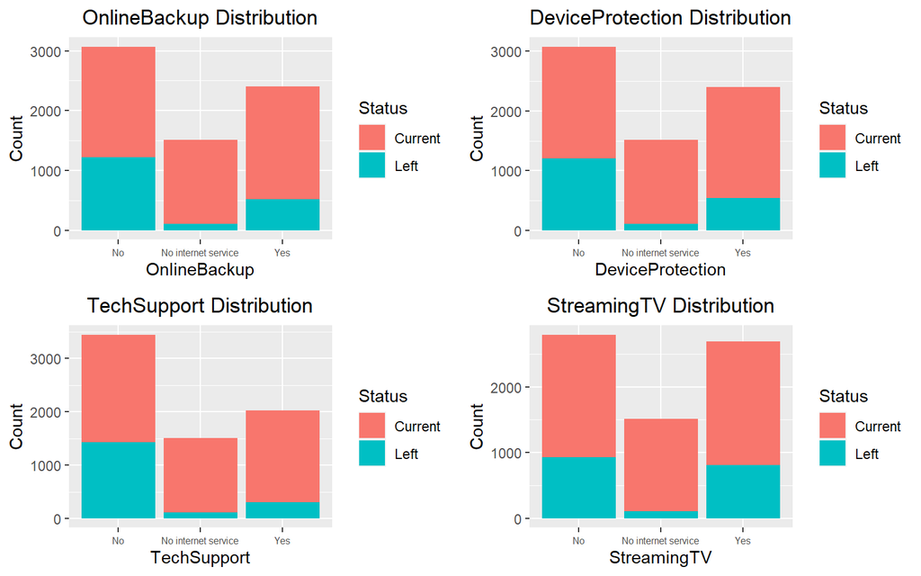

```r
plot_grid(plotlist = plot_list[9:12])
```

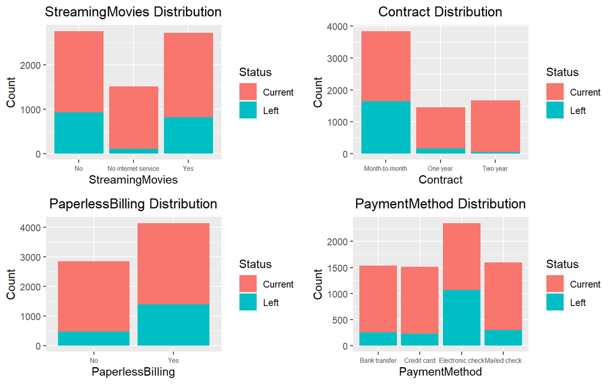

```r
plot_grid(plotlist = plot_list[13:16])
```

Now we are going to look at our numeric distributions:

```r
num_distribution <- function(y) {

  x = df[['Status']]
  var = df[[y]]

  ggplot() +
    geom_boxplot(aes(x, var, fill = x)) +
    labs(
      title = paste(y, "Distribution"),
      x = "Status",
      y = y,
      fill = 'Status'
    ) +
    theme(plot.title = element_text(hjust = 0.5))
}
```

```r
num_features <- colnames(
  df %>%
    select_if(is.numeric)
)

for (i in 1:length(num_features)) {
  col = num_features[i]
  print(num_distribution(col))
}
```

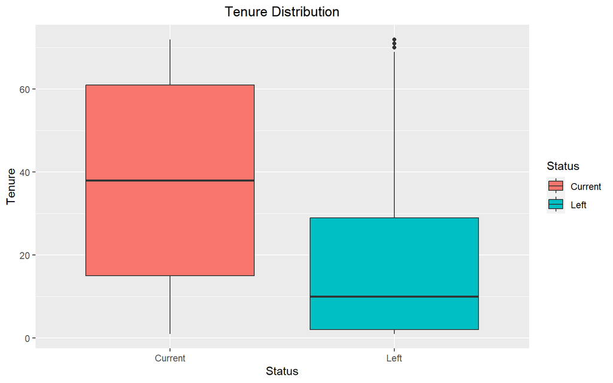

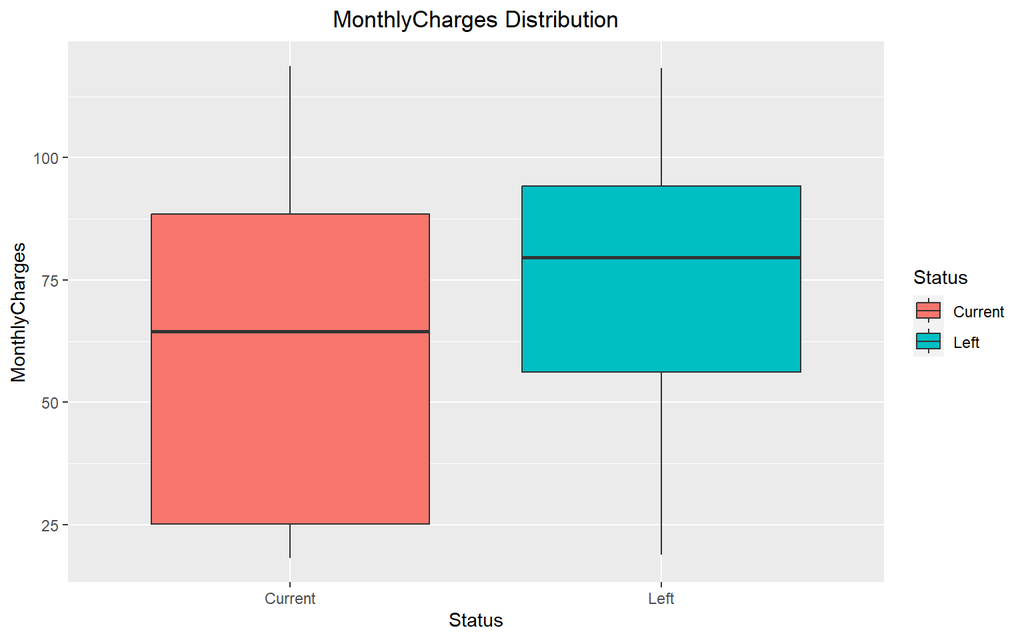

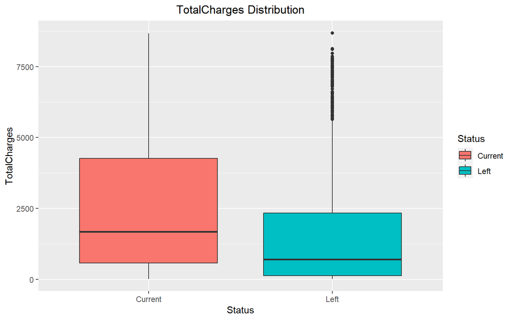

Some interesting insights we can make from looking at our distributions are:

- Customers who leave are leaving at a short period of time after signing up while current customers stay for a long time.
- Customers who are charged more in total were staying with the company longer.
- Customers who payed with electronic checks were more likely to leave.
- Customers who had month-to-month contracts were more likely to leave.

## Correlation Matrix

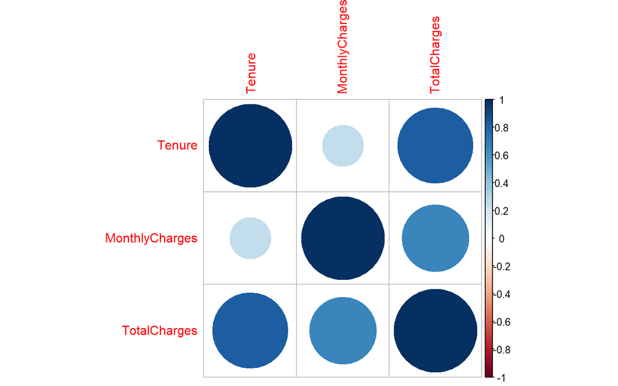

```r
df_cor <- df %>%
  select_if(is.numeric)

corrplot::corrplot(cor(df_cor))
```

There is a strong positive correlation between:

- Tenure and Total Charges
- Total Charges and Monthly Charges

Below we are going to look at Tenure by each payment method:

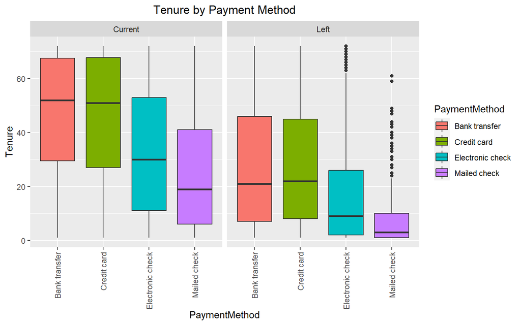

```r
ggplot(df) +
  geom_boxplot(aes(x = PaymentMethod, y = Tenure, fill = PaymentMethod)) +
  labs(
    title = 'Tenure by Payment Method'
  ) +
  theme(
    plot.title = element_text(hjust = 0.5),
    axis.text.x = element_text(angle = 90, vjust = 0.5, hjust = 1)
    ) +
  facet_wrap(vars(Status))
```

We can see that customers who payed with credit card or a bank transfer were more likely to stay around longer.

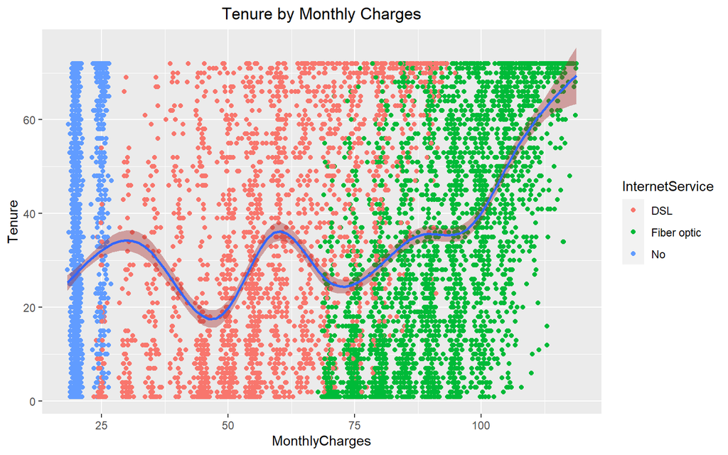

```r
ggplot(df) +
  geom_point(aes(y = Tenure, x = MonthlyCharges, color = InternetService)) +
  geom_smooth(
    aes(y = Tenure, x = MonthlyCharges), fill = 'brown'
    ) +
  labs(
    title = 'Tenure by Monthly Charges'
  ) +
  theme(
    plot.title = element_text(hjust = 0.5)
    )
```

From the chart above, we can see that:

- Fiber optic is the most expensive monthly internet service.
- Customers who payed more monthly for internet service stayed around longer.

# Data Processing

Lets create our train/test split and apply feature engineering steps to our $X$.

## Factoring Categorical Columns

```r
df <- df %>%
  mutate_if(is.character, as.factor)

fct_cols <- select_if(df, is.factor)
map(fct_cols, levels)
```

```
## $Gender
## [1] "Female" "Male"
##
## $SeniorCitizen
## [1] "No"  "Yes"
##
## $Partner
## [1] "No"  "Yes"
##
## $Dependents
## [1] "No"  "Yes"
##
## $PhoneService
## [1] "No"  "Yes"
##
## $MultipleLines
## [1] "No"               "No phone service" "Yes"
##
## $InternetService
## [1] "DSL"         "Fiber optic" "No"
##
## $OnlineSecurity
## [1] "No"                  "No internet service" "Yes"
##
## $OnlineBackup
## [1] "No"                  "No internet service" "Yes"
##
## $DeviceProtection
## [1] "No"                  "No internet service" "Yes"
##
## $TechSupport
## [1] "No"                  "No internet service" "Yes"
##
## $StreamingTV
## [1] "No"                  "No internet service" "Yes"
##
## $StreamingMovies
## [1] "No"                  "No internet service" "Yes"
##
## $Contract
## [1] "Month-to-month" "One year"       "Two year"
##
## $PaperlessBilling
## [1] "No"  "Yes"
##
## $PaymentMethod
## [1] "Bank transfer"    "Credit card"      "Electronic check" "Mailed check"
##
## $Status
## [1] "Current" "Left"
```

## Train/Test Split

```r
set.seed(123)
split <- initial_split(df, prop = 0.8, strata = Status)
train <- training(split)
test <- testing(split)

cv <- vfold_cv(train, v = 10, strata = Status)

cat('Training Shape:', paste0(dim(train), collapse = ','))
```

```
## Training Shape: 5589,20
```

```r
cat('Testing Shape:', paste0(dim(test), collapse = ','))
```

```
## Testing Shape: 1399,20
```

Training data preview:

```r
datatable(head(train))
```

|  | Gender | SeniorCitizen | Partner | Dependents | Tenure | PhoneService | MultipleLines | InternetService | OnlineSecurity | OnlineBackup | DeviceProtection | TechSupport | StreamingTV | StreamingMovies | Contract | PaperlessBilling | PaymentMethod | MonthlyCharges | TotalCharges | Status |
| --- | --- | --- | --- | --- | --- | --- | --- | --- | --- | --- | --- | --- | --- | --- | --- | --- | --- | --- | --- | --- |
| 1 | Female | No | Yes | No | 1 | No | No phone service | DSL | No | Yes | No | No | No | No | Month-to-month | Yes | Electronic check | 29.85 | 29.85 | Current |
| 2 | Male | No | No | No | 34 | Yes | No | DSL | Yes | No | Yes | No | No | No | One year | No | Mailed check | 56.95 | 1889.5 | Current |
| 3 | Male | No | No | No | 45 | No | No phone service | DSL | Yes | No | Yes | Yes | No | No | One year | No | Bank transfer | 42.3 | 1840.75 | Current |
| 4 | Female | No | No | No | 10 | No | No phone service | DSL | Yes | No | No | No | No | No | Month-to-month | No | Mailed check | 29.75 | 301.9 | Current |
| 5 | Male | No | Yes | Yes | 13 | Yes | No | DSL | Yes | No | No | No | No | No | Month-to-month | Yes | Mailed check | 49.95 | 587.45 | Current |
| 6 | Male | No | Yes | No | 58 | Yes | Yes | Fiber optic | No | No | Yes | No | Yes | Yes | One year | No | Credit card | 100.35 | 5681.1 | Current |

## Feature Engineering

```r
preprocessor <- recipe(Status ~ ., data = train) %>%
  step_dummy(all_nominal_predictors()) %>%
  step_normalize(all_numeric_predictors()) %>%
  step_YeoJohnson(all_numeric_predictors())
```

# Modeling

We are going to test 3 different algorithms:

- Random Forest
- KNN
- Gradient Boost

The model with the highest cross validated AUC will be used to predict future decisions.

## Random Forest

```r
rf <- rand_forest(
  mode = 'classification',
  trees = 250,
  mtry = 4,
  min_n = tune()
) %>%
  set_engine(engine = 'ranger')

rf_grid <- grid_regular(
  min_n(c(10, 20)),
  levels = 5
)

doParallel::registerDoParallel()
set.seed(123)

tune_rf <- tune_grid(
  rf,
  preprocessor,
  resamples = cv,
  grid = rf_grid,
  control = control_resamples(save_pred = T)
)

show_best(tune_rf, metric = 'roc_auc')
```

```
## # A tibble: 5 × 7
##   min_n .metric .estimator  mean     n std_err .config
##   <int> <chr>   <chr>      <dbl> <int>   <dbl> <chr>
## 1    17 roc_auc binary     0.851    10 0.00312 Preprocessor1_Model4
## 2    20 roc_auc binary     0.851    10 0.00329 Preprocessor1_Model5
## 3    10 roc_auc binary     0.850    10 0.00318 Preprocessor1_Model1
## 4    12 roc_auc binary     0.850    10 0.00333 Preprocessor1_Model2
## 5    15 roc_auc binary     0.850    10 0.00312 Preprocessor1_Model3
```

Lets get our CV metrics with the best hyper parameters:

```r
cross_val_score <- function(results, model) {

  best_params <- select_best(results, metric = 'roc_auc')

  mdl <- workflow() %>%
    add_model(model) %>%
    add_recipe(preprocessor) %>%
    finalize_workflow(best_params)

  set.seed(123)
  cv_scores <- mdl %>%
  fit_resamples(cv) %>%
  collect_metrics()

  return(cv_scores)

}
```

```r
rf_score <- cross_val_score(tune_rf, rf)
rf_score
```

```
## # A tibble: 2 × 6
##   .metric  .estimator  mean     n std_err .config
##   <chr>    <chr>      <dbl> <int>   <dbl> <chr>
## 1 accuracy binary     0.805    10 0.00315 Preprocessor1_Model1
## 2 roc_auc  binary     0.851    10 0.00316 Preprocessor1_Model1
```

Confusion matrix for our cross validated procedure:

```r
conf_mat_resampled(
  tune_rf,
  select_best(tune_rf, metric = 'roc_auc'),
  tidy = F
  )
```

```
##         Current  Left
## Current   375.4  74.4
## Left       35.1  74.0
```

## KNN

```r
knn <- nearest_neighbor(
  mode = 'classification',
  engine = 'kknn',
  neighbors = tune(),
  weight_func = 'rectangular'
)

knn_params <- grid_regular(
  neighbors(range = c(1, 101)),
  levels = 10
)

doParallel::registerDoParallel()
set.seed(123)

knn_grid_search <- tune_grid(
  knn,
  preprocessor,
  cv,
  grid = knn_params,
  control = control_resamples(save_pred = T)
  )

show_best(knn_grid_search, metric = 'roc_auc')
```

```
## # A tibble: 5 × 7
##   neighbors .metric .estimator  mean     n std_err .config
##       <int> <chr>   <chr>      <dbl> <int>   <dbl> <chr>
## 1        78 roc_auc binary     0.838    10 0.00352 Preprocessor1_Model08
## 2        67 roc_auc binary     0.838    10 0.00349 Preprocessor1_Model07
## 3        89 roc_auc binary     0.838    10 0.00322 Preprocessor1_Model09
## 4        56 roc_auc binary     0.838    10 0.00364 Preprocessor1_Model06
## 5       101 roc_auc binary     0.837    10 0.00272 Preprocessor1_Model10
```

```r
knn_score <- cross_val_score(knn_grid_search, knn)
knn_score
```

```
## # A tibble: 2 × 6
##   .metric  .estimator  mean     n std_err .config
##   <chr>    <chr>      <dbl> <int>   <dbl> <chr>
## 1 accuracy binary     0.795    10 0.00373 Preprocessor1_Model1
## 2 roc_auc  binary     0.838    10 0.00352 Preprocessor1_Model1
```

Confusion matrix for our cross validated procedure:

```r
conf_mat_resampled(
  knn_grid_search,
  select_best(knn_grid_search, metric = 'roc_auc'),
  tidy = F
  )
```

```
##         Current  Left
## Current   358.0  61.8
## Left       52.5  86.6
```

## Gradient Boost

```r
boost <- boost_tree(
  mode = 'classification',
  engine = "xgboost",
  trees = 250,
  mtry = tune(),
  learn_rate = tune(),
  tree_depth = tune(),
  loss_reduction = tune(),
  sample_size = tune()
    )

boost_params <- grid_latin_hypercube(
  tree_depth(),
  finalize(mtry(), train),
  loss_reduction(),
  sample_size = sample_prop(),
  learn_rate(),
  size = 30
)

doParallel::registerDoParallel()
set.seed(123)

tune_boost <- tune_grid(
  boost,
  preprocessor,
  resamples = cv,
  grid = boost_params,
  control = control_resamples(save_pred = T)
)
```

```r
show_best(tune_boost, metric = 'roc_auc')
```

```
## # A tibble: 5 × 11
##    mtry tree_depth learn_r…¹ loss_…² sampl…³ .metric .esti…⁴  mean     n std_err
##   <int>      <int>     <dbl>   <dbl>   <dbl> <chr>   <chr>   <dbl> <int>   <dbl>
## 1     3          3   2.30e-2 4.31e-8   0.445 roc_auc binary  0.852    10 0.00310
## 2     6         12   5.76e-4 5.26e-2   0.830 roc_auc binary  0.851    10 0.00309
## 3     9          8   1.05e-3 8.43e-1   0.694 roc_auc binary  0.850    10 0.00324
## 4     5          9   3.96e-7 1.81e-1   0.636 roc_auc binary  0.850    10 0.00329
## 5     5         12   4.58e-5 5.04e-7   0.357 roc_auc binary  0.850    10 0.00320
## # … with 1 more variable: .config <chr>, and abbreviated variable names
## #   ¹learn_rate, ²loss_reduction, ³sample_size, ⁴.estimator
```

```r
boost_score <- cross_val_score(tune_boost, boost)
boost_score
```

```
## # A tibble: 2 × 6
##   .metric  .estimator  mean     n std_err .config
##   <chr>    <chr>      <dbl> <int>   <dbl> <chr>
## 1 accuracy binary     0.804    10 0.00330 Preprocessor1_Model1
## 2 roc_auc  binary     0.852    10 0.00282 Preprocessor1_Model1
```

Confusion matrix for our cross validated procedure:

```r
conf_mat_resampled(
  tune_boost,
  select_best(tune_boost, metric = 'roc_auc'),
  tidy = F
  )
```

```
##         Current  Left
## Current   375.0  73.9
## Left       35.5  74.5
```

```r
# function for getting metrics
get_metric <- function(model_score, metric) {
  score <- model_score %>%
    filter(.metric == metric)

  return(score$mean)
}
```

# Results

We are going to first get our accuracy scores from each model:

```r
scores <- list(rf_score, knn_score, boost_score)

accuracy_scores <- c()

for (x in scores) {
  val <- get_metric(model_score = x, metric = 'accuracy')
  accuracy_scores[[length(accuracy_scores) + 1]] <- val
}

accuracy_scores <- unlist(accuracy_scores, use.names = FALSE)
```

Now we are going to get our AUC scores from our models:

```r
roc_auc_scores = c()

for (x in scores) {
  val <- get_metric(model_score = x, metric = 'roc_auc')
  roc_auc_scores[[length(roc_auc_scores) + 1]] <- val
}

roc_auc_scores <- unlist(roc_auc_scores, use.names = FALSE)
```

Below we are going to plot our model performances:

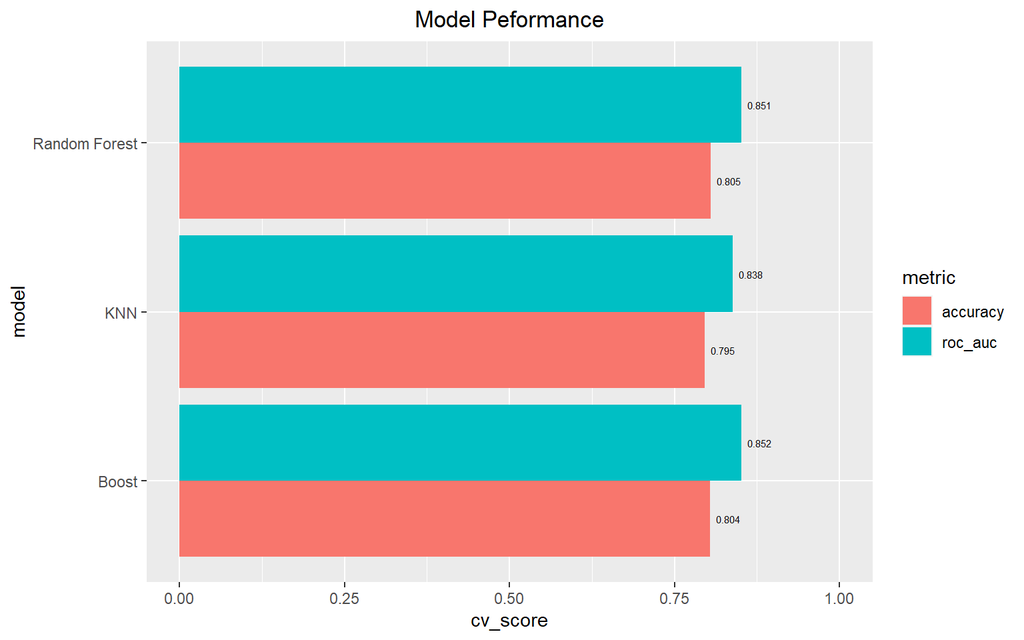

```r
results_df <- data.frame(
  model = rep(c('Random Forest', 'KNN', "Boost"), times = ),
  metric = rep(c('accuracy', 'roc_auc'), each = 3),
  cv_score = c(accuracy_scores, roc_auc_scores)
)

ggplot(results_df, aes(x = model, y = cv_score, fill = metric)) +
  geom_col(position = 'dodge') +
  coord_flip() +
  ylim(0, 1) +
  geom_text(
    label = round(results_df$cv_score, digits = 3),
    position = position_dodge(width = .9),
    hjust = -0.25,
    size = 2
    ) +
  labs(
    title = 'Model Peformance'
  ) +
  theme(
    plot.title = element_text(hjust = 0.5)
  )
```

Above we can see that our Boosting and Random Forest models performed just as well as each other, with our Gradient Boost model having just a tiny bit better AUC score of **85.2% (80.4% accuracy).**

# Testing Best Model

Below we are going to test our Gradient Boost model on unseen data:

```r
boost_wf <- workflow() %>%
  add_recipe(preprocessor) %>%
  add_model(boost) %>%
  finalize_workflow(select_best(tune_boost, metric = 'roc_auc'))

boost_fit <- boost_wf %>%
  fit(data = train)

set.seed(123)
prediction <- boost_fit %>%
  predict(test) %>%
  bind_cols(select(test, Status))

conf_mat <- prediction %>%
  conf_mat(Status, .pred_class)

acc <- prediction %>%
  accuracy(Status, .pred_class)
```

## Metrics

```r
# Accuracy
acc
```

```
## # A tibble: 1 × 3
##   .metric  .estimator .estimate
##   <chr>    <chr>          <dbl>
## 1 accuracy binary         0.794
```

```r
# Confusion Matrix
conf_mat
```

```
##           Truth
## Prediction Current Left
##    Current     927  188
##    Left        100  184
```

We can see that most of our inefficiencies in our model came from False Positives that they are still current. Below is the feature importance plot for this graph:

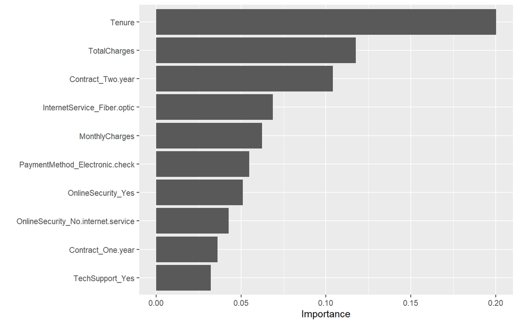

```r
boost_fit %>%
  extract_fit_parsnip() %>%
  vip()
```

Two Year Contracts, Tenure, and Total Charges were the most important features in the Boost Model. As we saw in our data analysis, loyal customers with a two year contract are most likely not to churn than any other contract.

Below we will look at the partial dependencies for *Tenure* and *TotalCharges*:

```r
predict_plot <- function(var, model) {
  explainer_lg <- explain_tidymodels(
    model,
    data = select(train, -Status),
    y = as.integer(train$Status)
  )

  pdp <- model_profile(
    explainer = explainer_lg,
    variables = var,
    N = NULL
  )

  pdp_df <- as_tibble(pdp$agr_profiles)
  print(
  ggplot(pdp_df, aes(x = `_x_`, y = `_yhat_`)) +
    geom_smooth(color = 'lightblue', se = F) +
    ylim(0, 1) +
    labs(
      title = paste(str_to_title(var), 'Partial Prediction'),
      x = var
    ) +
    theme_dark() +
    theme(plot.title = element_text(hjust = 0.5))
  )
}
```

[output not shown]

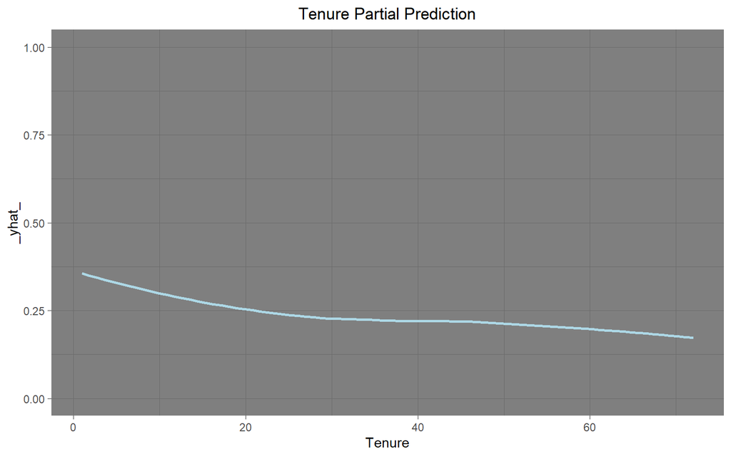

```r
predict_plot(var = 'Tenure', model = boost_fit)
```

The longer one stays with the company, the less likely they are to churn.

[output not shown]

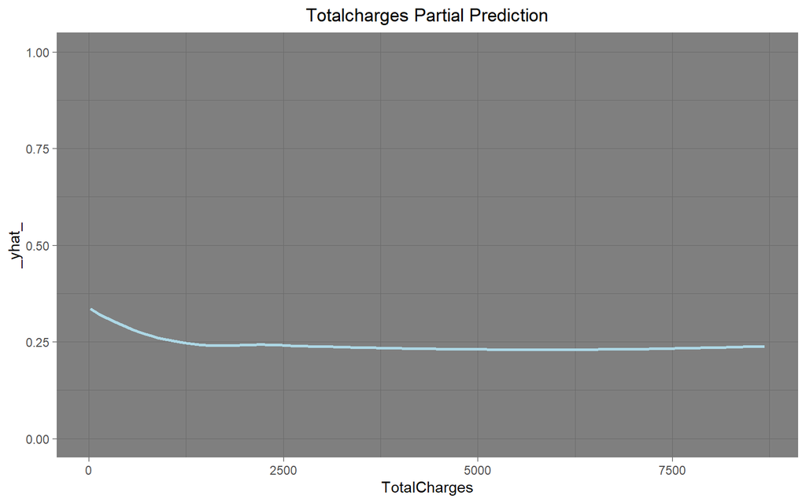

```r
predict_plot('TotalCharges', boost_fit)
```

The higher the total charges, the less one is to churn, signifying loyalty to the company to stay around longer.

# Moving Forward

From our model, we understand that customers who stick around longer tend to stay with the company, meaning most customers churn very shortly after signing up rather than if they stay for a long time.